# In-Class Data Exploration 2

September 27, 2022

#Load packages

```r
require(psych)
```

#Load datasets

```r
dat_bird <- read.csv(here("data", "bird.sta.csv"))
dat_habitat <-  read.csv(here("data", "hab.sta.csv"))
```

#Bird habitat data exploration

```r
colnames(dat_habitat)
```

```
 [1] "basin"    "sub"      "sta"      "lat"      "long"     "elev"     "slope"
 [8] "aspect"   "s.id"     "s.edge"   "p.edge"   "p.edge.1" "p.cwedge" "ba.con"
[15] "ba.hard"  "ba.snag"  "ba.tot"   "ba.ratio" "snag.sml" "snag.ml"  "snag.l"
[22] "snag.dc1" "snag.dc2" "snag.dc4"
```

#Bird count data Use the hist() function to explore the distributions of counts of birds at the various study sites.

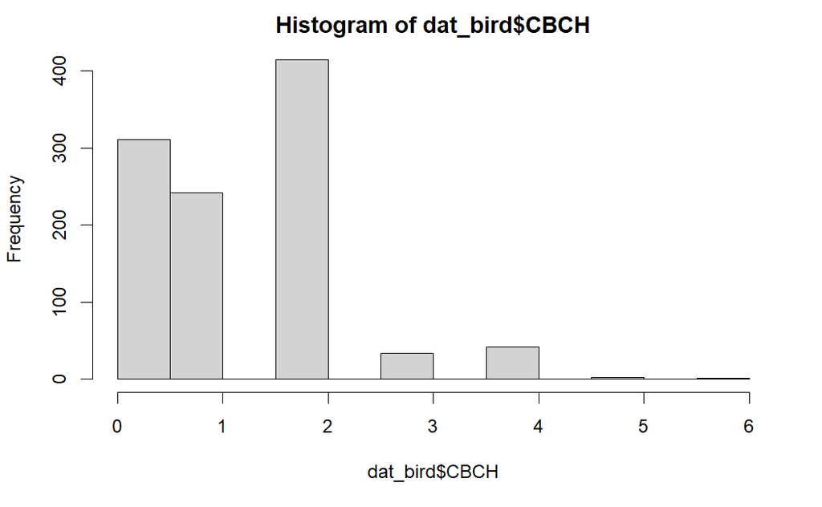

I used the arguments xlab = “Number of birds counted” and breaks = 0:7 - 0.5 with hist() to produce the following:

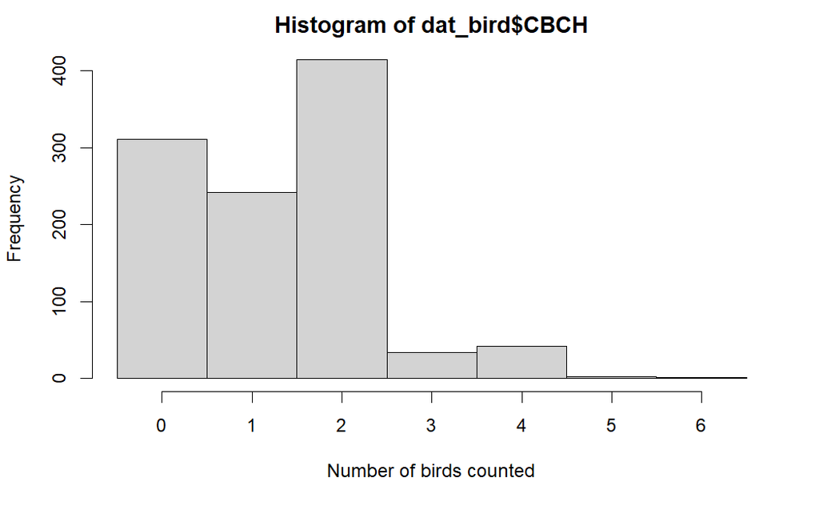

#Bird Count Histograms Create some histograms of bird counts. Experiment with the breaks argument.

You may want to try to re-create my histogram above as a first step.

If your breaks argument does not span the range of count values you will get an error. You may need to try a higher upper limit. You could also use the max() function to determine the highest number of counts of your bird species column.

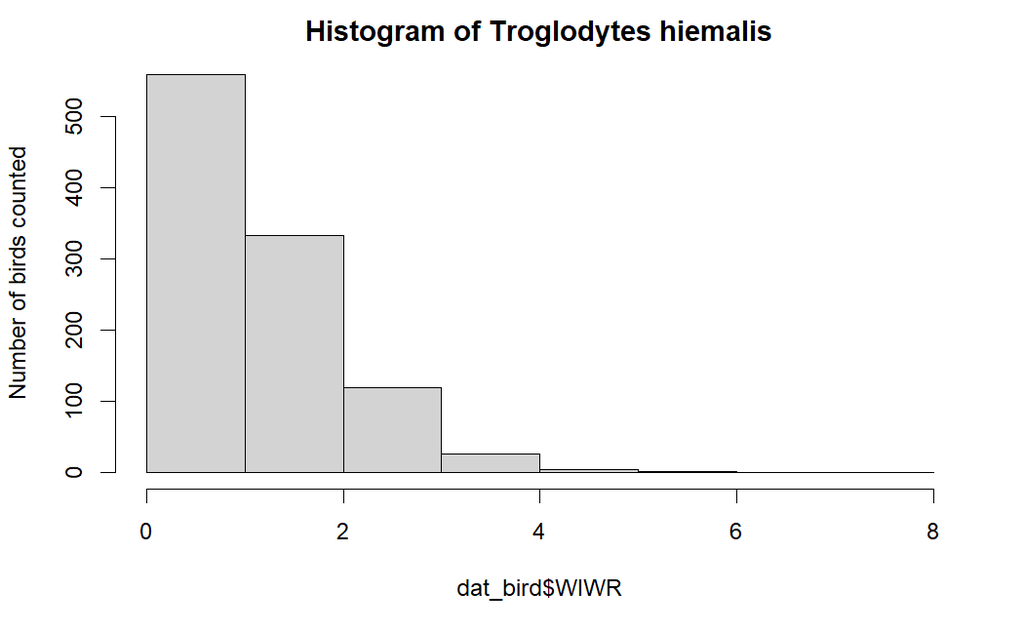

## Instructions

As a group you should work through the following:

#Import the datasets, and take a look at the metadata. #Explore the habitat data using pair plots.

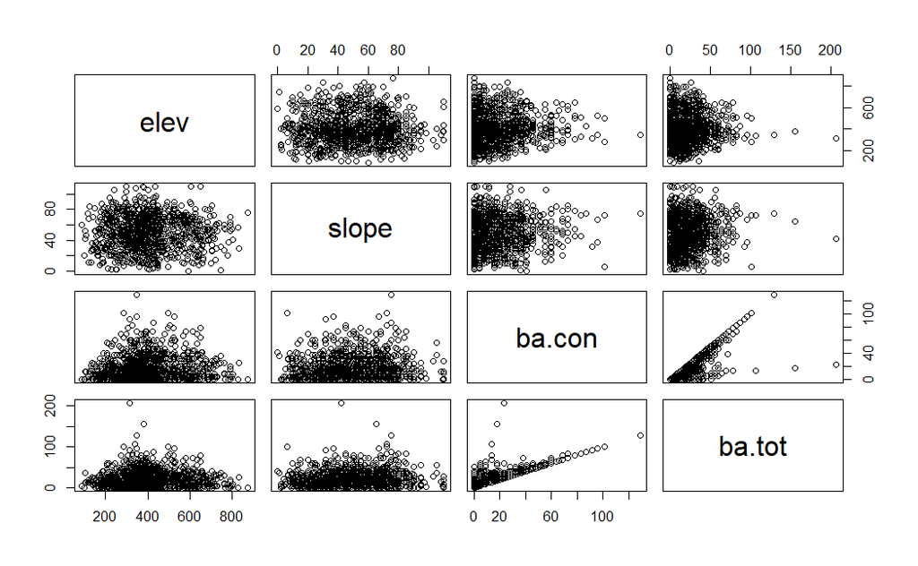

Explore the distributions of counts of bird species using histograms.

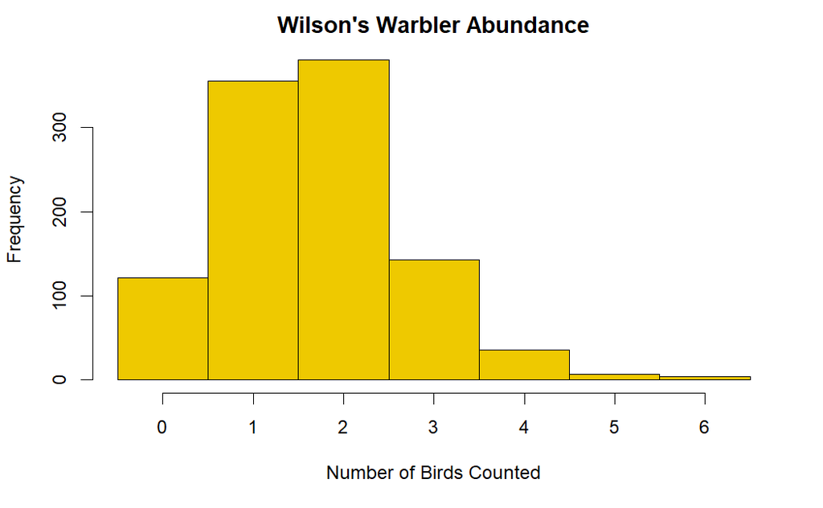